# ¿Por qué estudiar Series de Tiempo?

Un caso de consultoría con Tiendas 3B en la Ciudad de México

Rodrigo B.

# Planteamiento

La cadena **Tiendas 3B** contrata un servicio de consultoría para analizar su operación en la **Ciudad de México**. Se tiene disponible un registro **mensual** de sus operaciones en la ciudad de los últimos 6 años, así como la huella de tiendas por alcaldía.

En principio, el objetivo es reportar **business insights** (información relevante que se obtiene al analizar los datos y ayuda a la toma de decisiones) sobre la operación de la empresa y si es posible, realizar un pronóstico de ingresos para los próximos meses.

Se tiene disponible la siguiente información:

## **1. Operación mensual en la CDMX** (72 observaciones, enero 2019 – diciembre 2024)

| Variable | Descripción |
| --- | --- |
| `fecha` | Mes al que corresponde el registro. |
| `ingresos` | Ingresos totales del mes en la CDMX, en millones de pesos. |
| `gasto_publicidad` | Monto invertido en publicidad/marketing ese mes, en millones de pesos. |
| `ticket_promedio` | Ticket promedio de compra por cliente, en pesos. |
| `num_clientes` | Número de transacciones (clientes) registradas ese mes. |

## **2. Huella de tiendas por alcaldía**

| Alcaldia | num_tiendas | ingreso_prom_tienda |
| --- | --- | --- |
| Azcapotzalco | 9 | 0.81 |
| Coyoacán | 22 | 0.97 |
| Cuajimalpa de Morelos | 6 | 1.08 |
| Gustavo A. Madero | 15 | 1.00 |
| Iztacalco | 19 | 0.99 |
| Iztapalapa | 15 | 1.04 |
| La Magdalena Contreras | 8 | 0.93 |
| Milpa Alta | 21 | 0.92 |
| Álvaro Obregón | 8 | 0.74 |

# Explorando los datos: `La presencia de Tiendas 3B en la CDMX`

Un primer acercamiento a los datos puede ser la distribución de las sucursales entre las 16 alcaldías. Para visualizar mapas de México usamos el paquete `mxmaps` de `R`.

[interactive chart not shown]

Figure 1: Mapa de alcaldías de la Ciudad de México con presencia de Tiendas 3B

También podemos visualizar el **ingreso promedio por tienda** en cada alcaldía.

[interactive chart not shown]

Figure 2: Mapa de ingresos por alcaldía

Algunos comentarios:

- Como parte de la visualización es indispensable mantener la dependencia geográfica de los datos, pues zonas cercanas tienden a tener características similares (por ejemplo, alcaldías con mayor poder adquisitivo). Los modelos de estadística espacial (que no veremos) permiten capturar esta dependencia explícitamente.
- En esta etapa, solo nos interesa **describir** patrones interesantes.
- Una propuesta sería presentar ambos mapas, mencionar los patrones observados (zonas de la ciudad con mayor presencia de tiendas y zonas con mayor ingreso promedio por tienda) y posteriormente tratar de explicar estos patrones con conocimiento del contexto (por ejemplo, las alcaldías con mayor ingreso promedio por tienda no necesariamente son las que tienen más tiendas).

## Correlograma

Analizar las correlaciones puede ayudar a identificar anticipadamente problemas, o si el razonable el uso de técnicas de análisis multivariado para reducir la dimensión del dataset (como PCA). Debido a la naturaleza de los datos, era de esperarse que hubiera una fuerte correlación entre ellas.

[interactive chart not shown]

Figure 3

## Publicidad vs. Ingresos

Podríamos analizar con mayor detalle la variable que presenta una menor correlación (lineal).

[interactive chart not shown]

Figure 4

# Trabajar con lo que hay: `Un modelo de regresión lineal múltiple`

Ante la falta de conocimiento de otros modelos, puede ser tentador tratar de aplicar un modelo de regresión lineal para explicar los ingresos de Tiendas 3B en la CDMX.

El modelo de efectos principales sería:

$$\mathbb{E}[\text{ingresos} | \text{gasto_publicidad}, \text{ticket_promedio}, \text{num_clientes}]$$

$$= \beta_0 + \beta_1 \text{gasto_publicidad} + \beta_2 \text{ticket_promedio} + \beta_3 \text{num_clientes}$$

Este modelo no parece pertinente, pues el correlograma sugiere un problema de multicolinealidad entre las covariables, y tal vez sea necesario realizar una selección de las mismas.

```
Call:
lm(formula = ingresos ~ gasto_publicidad + ticket_promedio +
    num_clientes, data = ventas)

Residuals:
     Min       1Q   Median       3Q      Max
-18.2196  -6.0270   0.9737   5.6839  15.7443

Coefficients:
                   Estimate Std. Error t value Pr(>|t|)
(Intercept)      -1.361e+02  2.699e+01  -5.044 3.62e-06 ***
gasto_publicidad  1.314e+00  5.276e-01   2.491  0.01517 *
ticket_promedio   7.281e-01  2.698e-01   2.699  0.00877 **
num_clientes      5.065e-04  1.915e-04   2.645  0.01013 *
---
Signif. codes:  0 '***' 0.001 '**' 0.01 '*' 0.05 '.' 0.1 ' ' 1

Residual standard error: 8.444 on 68 degrees of freedom
Multiple R-squared:  0.6928,    Adjusted R-squared:  0.6793
F-statistic: 51.12 on 3 and 68 DF,  p-value: < 2.2e-16
```

Una mejor propuesta podría ser el modelo

$$\mathbb{E}[\text{ingresos} | \text{num_clientes}] = \beta_0 + \beta_1 \text{num_clientes}$$

```
Call:
lm(formula = ingresos ~ num_clientes, data = ventas)

Residuals:
     Min       1Q   Median       3Q      Max
-18.1695  -6.2847  -0.6223   6.1763  20.9393

Coefficients:
               Estimate Std. Error t value Pr(>|t|)
(Intercept)  -6.712e+01  1.575e+01   -4.26 6.25e-05 ***
num_clientes  9.633e-04  8.755e-05   11.00  < 2e-16 ***
---
Signif. codes:  0 '***' 0.001 '**' 0.01 '*' 0.05 '.' 0.1 ' ' 1

Residual standard error: 9.089 on 70 degrees of freedom
Multiple R-squared:  0.6336,    Adjusted R-squared:  0.6284
F-statistic: 121.1 on 1 and 70 DF,  p-value: < 2.2e-16
```

## Sacándole provecho: Inferencia sobre coeficientes

Las estimaciones de los parámetros del modelo $\beta_0$ y $\beta_1$ son fáciles de interpretar. Podría ser de interés plantear pruebas de hipótesis avanzadas con la Prueba Lineal General.

| term | estimate | std.error | statistic | p.value | conf.low | conf.high |
| --- | --- | --- | --- | --- | --- | --- |
| (Intercept) | -67.1211 | 15.7544 | -4.2605 | 1e-04 | -98.5424 | -35.6999 |
| num_clientes | 0.0010 | 0.0001 | 11.0029 | 0e+00 | 0.0008 | 0.0011 |

## Métricas de evaluación

Algunas métricas como la $R^2$ ayudan a evaluar el porcentaje de varianza explicada por el modelo, mientras que el AIC y BIC ayuda a realizar comparación entre modelos.

| r.squared | adj.r.squared | p.value | AIC | BIC |
| --- | --- | --- | --- | --- |
| 0.6336 | 0.6284 | 0 | 526.113 | 532.943 |

## Predicción

El equipo de marketing de Tiendas 3B espera que el próximo mes haya 130,000 clientes en toda la CDMX, nuestro modelo permite incorporar el efecto del número de clientes en la predicción de los ingresos.

| fit | lwr | upr |
| --- | --- | --- |
| 58.1024 | 37.904 | 78.3009 |

## ¿Validamos los supuestos?

Existen herramientas gráicas que ayudan a diagnosticar el modelo, así como pruebas de hipótesis para la homocedasticidad, normalidad de los errores e independencia.

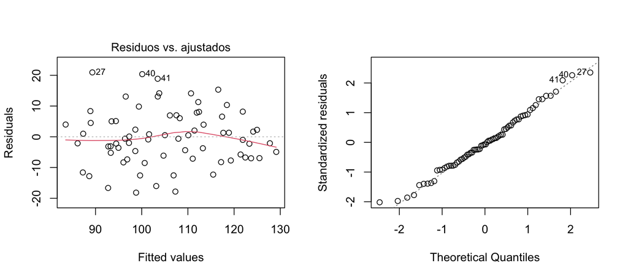

Figure 5

## Las limitaciones de fondo

¿Lo resuelve la regresión clásica?

- ¿Qué variables explican los ingresos? Sí
- ¿Existe una tendencia de largo plazo? No la modela explícitamente
- ¿Hay un patrón estacional (meses altos/bajos)? No la modela explícitamente
- ¿Cuánto dependen los ingresos de sí mismos en el pasado? No lo captura
- ¿Puedo pronosticar *h* meses adelante con un margen de incertidumbre? No

# Reconociendo el tiempo

## ¿Qué cambia si modelamos la dependencia temporal?

En vez de tratar cada fila como intercambiable, construimos un objeto que **preserva el orden y la periodicidad** de las observaciones:

```
       Jan   Feb   Mar   Apr   May   Jun   Jul   Aug   Sep   Oct   Nov   Dec
2019 88.33 87.52 93.47 90.19 91.37 92.26 84.00 80.62 75.85 76.09 75.67 88.09
2020 92.13
```

Ahora el modelo puede “ver” que enero de 2020 sigue a diciembre de 2019, y que ambos son parte de un ciclo anual de 12 meses.

## Estacionalidad por mes

Si ignoramos que estos datos tienen un orden temporal y creamos a la variable categórica ordinal `mes`.

[interactive chart not shown]

Figure 6

## Visualizando la serie de tiempo

[interactive chart not shown]

Figure 7

## Proximamente

- Estacionariedad y transformaciones (diferenciación, logaritmos)
- Autocorrelación: ACF y PACF como herramientas de diagnóstico
- Descomposición clásica
- Suavizamiento y estimación de ciclicidad
- Modelos ARIMA / SARIMA
- Incorporación de covariables externas (ARIMAX)
- Evaluación y validación de pronósticos